# ReporteArboles

Flavio Galán, José Prince

2025-03-10

Link del repositorio: https://github.com/ElrohirGT/Proyecto2_MineriaDeDatos

## Árbol multivariable

```r
# install.packages("rpart")       # Árboles de regresión
# install.packages("rpart.plot")  # Gráfico bonito del árbol

# Cargar librerías
library(rpart)
library(rpart.plot)
load_data()

# Crear el árbol de regresión
modelo_arbol <- rpart(SalePrice ~ ., data = training_data)

# Ver el resumen del árbol
summary(modelo_arbol)
```

```
## Call:
## rpart(formula = SalePrice ~ ., data = training_data)
##   n= 1460
##
##            CP nsplit rel error    xerror       xstd
## 1  0.45437625      0 1.0000000 1.0011849 0.07639056
## 2  0.12050238      1 0.5456237 0.5482263 0.04133351
## 3  0.06288535      2 0.4251214 0.4276896 0.04017915
## 4  0.03312902      3 0.3622360 0.3869062 0.03058238
## 5  0.02066528      4 0.3291070 0.3594559 0.03002544
## 6  0.01989959      5 0.3084417 0.3835037 0.03894033
## 7  0.01856908      6 0.2885421 0.3685155 0.03657763
## 8  0.01392462      7 0.2699730 0.3499217 0.03382312
## 9  0.01129700      8 0.2560484 0.3373653 0.03377663
## 10 0.01016483      9 0.2447514 0.3260877 0.03354712
## 11 0.01000000     10 0.2345866 0.3245808 0.03341045
##
## Variable importance
##  OverallQual Neighborhood   GarageCars  KitchenQual  TotalBsmtSF   GarageArea
##           28           14            7            7            7            7
##    GrLivArea    ExterQual    YearBuilt     BsmtQual   Foundation    X2ndFlrSF
##            5            4            4            4            3            2
## TotRmsAbvGrd   HouseStyle    X1stFlrSF BedroomAbvGr   BsmtFinSF1           Id
##            2            1            1            1            1            1
##   GarageType
##            1
##
## Node number 1: 1460 observations,    complexity param=0.4543763
##   mean=180921.2, MSE=6.306789e+09
##   left son=2 (1231 obs) right son=3 (229 obs)
##   Primary splits:
##       OverallQual  < 7.5     to the left,  improve=0.4543763, (0 missing)
##       ExterQual    splits as  RLRL, improve=0.3786159, (0 missing)
##       GarageCars   < 2.5     to the left,  improve=0.3650136, (0 missing)
##       Neighborhood splits as  LLLLLLLLLLLLLRLRLLLLRRLRR, improve=0.3460826, (0 missing)
##       GrLivArea    < 1488    to the left,  improve=0.3280228, (0 missing)
##   Surrogate splits:
##       Neighborhood splits as  LLLLLLLLLLLLLRLRLLLLLRLLL, agree=0.896, adj=0.336, (0 split)
##       GarageCars   < 2.5     to the left,  agree=0.895, adj=0.332, (0 split)
##       GarageArea   < 690.5   to the left,  agree=0.888, adj=0.288, (0 split)
```

[output cut: 164 more lines]

```
##
## Node number 21: 287 observations
##   mean=185210.3, MSE=7.858899e+08
##
## Node number 22: 138 observations
##   mean=217077.2, MSE=1.219806e+09
##
## Node number 23: 30 observations
##   mean=278706.2, MSE=1.979047e+09
##
## Node number 30: 16 observations
##   mean=402070.3, MSE=7.06213e+09
##
## Node number 31: 10 observations
##   mean=532083.9, MSE=2.97708e+10
```

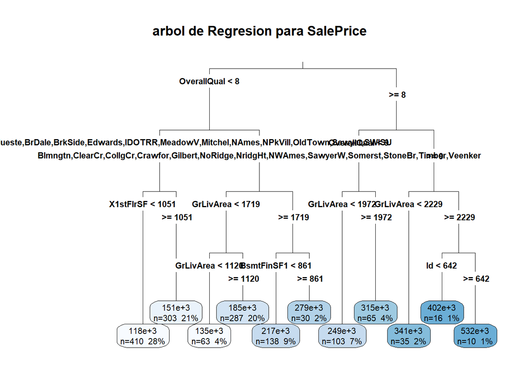

```r
# Gráfico simple
rpart.plot(modelo_arbol, type = 3, extra = 101, fallen.leaves = TRUE, cex = 0.7, main = "arbol de Regresion para SalePrice")
```

Ahora vamos a medir la precisión del modelo:

```r
predicciones <- predict(modelo_arbol, training_data)

SSE <- sum((training_data$SalePrice - predicciones)^2)
SST <- sum((training_data$SalePrice - mean(training_data$SalePrice))^2)
R2 <- 1 - (SSE / SST)
cat("R-squared:", R2, "\n")
```

```
## R-squared: 0.7654134
```

```r
RMSE <- sqrt(mean((training_data$SalePrice - predicciones)^2))
cat("RMSE:", RMSE)
```

```
## RMSE: 38464.11
```

Este modelo predice la data con un 76% de variabilidad, además su RMSE es de 38 mil dólares lo cual sigue siendo alto aunque más bajo que el de los lineales.

## Árboles de varios niveles

Ahora vamos a generar árboles con varios niveles de profundidad:

```r
# Cargar librerías
library(rpart)
library(rpart.plot)

load_data()

# Crear el árbol de regresión
arbol_2 <- rpart(SalePrice ~ ., data = training_data, control = rpart.control(maxdepth = 2))
arbol_3 <- rpart(SalePrice ~ ., data = training_data, control = rpart.control(maxdepth = 3))
arbol_8 <- rpart(SalePrice ~ ., data = training_data, control = rpart.control(maxdepth = 8))

# Ver el resumen del árbol
summary(modelo_arbol)
```

```
## Call:
## rpart(formula = SalePrice ~ ., data = training_data)
##   n= 1460
##
##            CP nsplit rel error    xerror       xstd
## 1  0.45437625      0 1.0000000 1.0011849 0.07639056
## 2  0.12050238      1 0.5456237 0.5482263 0.04133351
## 3  0.06288535      2 0.4251214 0.4276896 0.04017915
## 4  0.03312902      3 0.3622360 0.3869062 0.03058238
## 5  0.02066528      4 0.3291070 0.3594559 0.03002544
## 6  0.01989959      5 0.3084417 0.3835037 0.03894033
## 7  0.01856908      6 0.2885421 0.3685155 0.03657763
## 8  0.01392462      7 0.2699730 0.3499217 0.03382312
## 9  0.01129700      8 0.2560484 0.3373653 0.03377663
## 10 0.01016483      9 0.2447514 0.3260877 0.03354712
## 11 0.01000000     10 0.2345866 0.3245808 0.03341045
##
## Variable importance
##  OverallQual Neighborhood   GarageCars  KitchenQual  TotalBsmtSF   GarageArea
##           28           14            7            7            7            7
##    GrLivArea    ExterQual    YearBuilt     BsmtQual   Foundation    X2ndFlrSF
##            5            4            4            4            3            2
## TotRmsAbvGrd   HouseStyle    X1stFlrSF BedroomAbvGr   BsmtFinSF1           Id
##            2            1            1            1            1            1
##   GarageType
##            1
##
## Node number 1: 1460 observations,    complexity param=0.4543763
##   mean=180921.2, MSE=6.306789e+09
##   left son=2 (1231 obs) right son=3 (229 obs)
##   Primary splits:
##       OverallQual  < 7.5     to the left,  improve=0.4543763, (0 missing)
##       ExterQual    splits as  RLRL, improve=0.3786159, (0 missing)
##       GarageCars   < 2.5     to the left,  improve=0.3650136, (0 missing)
##       Neighborhood splits as  LLLLLLLLLLLLLRLRLLLLRRLRR, improve=0.3460826, (0 missing)
##       GrLivArea    < 1488    to the left,  improve=0.3280228, (0 missing)
##   Surrogate splits:
##       Neighborhood splits as  LLLLLLLLLLLLLRLRLLLLLRLLL, agree=0.896, adj=0.336, (0 split)
##       GarageCars   < 2.5     to the left,  agree=0.895, adj=0.332, (0 split)
##       GarageArea   < 690.5   to the left,  agree=0.888, adj=0.288, (0 split)
```

[output cut: 164 more lines]

```
##
## Node number 21: 287 observations
##   mean=185210.3, MSE=7.858899e+08
##
## Node number 22: 138 observations
##   mean=217077.2, MSE=1.219806e+09
##
## Node number 23: 30 observations
##   mean=278706.2, MSE=1.979047e+09
##
## Node number 30: 16 observations
##   mean=402070.3, MSE=7.06213e+09
##
## Node number 31: 10 observations
##   mean=532083.9, MSE=2.97708e+10
```

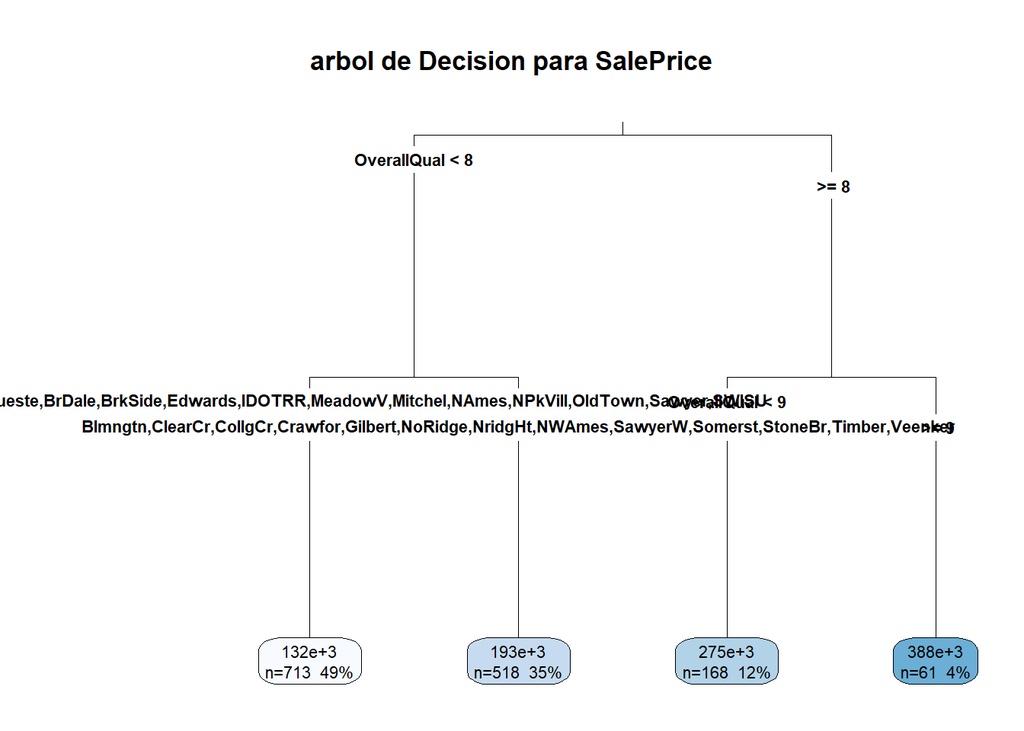

```r
# Gráfico simple
rpart.plot(arbol_2, type = 3, extra = 101, fallen.leaves = TRUE, cex = 0.7, main = "arbol de Decision para SalePrice")
```

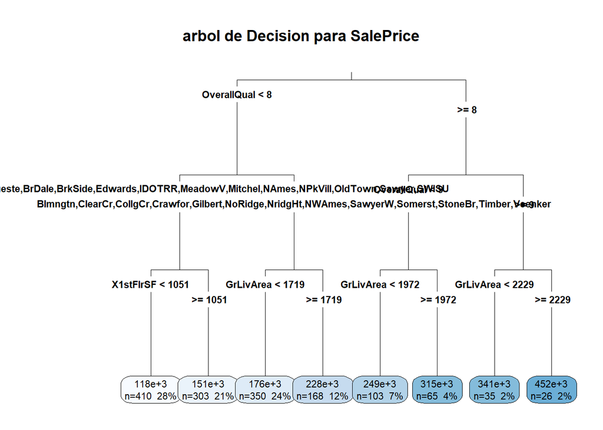

```r
rpart.plot(arbol_3, type = 3, extra = 101, fallen.leaves = TRUE, cex = 0.7, main = "arbol de Decision para SalePrice")
```

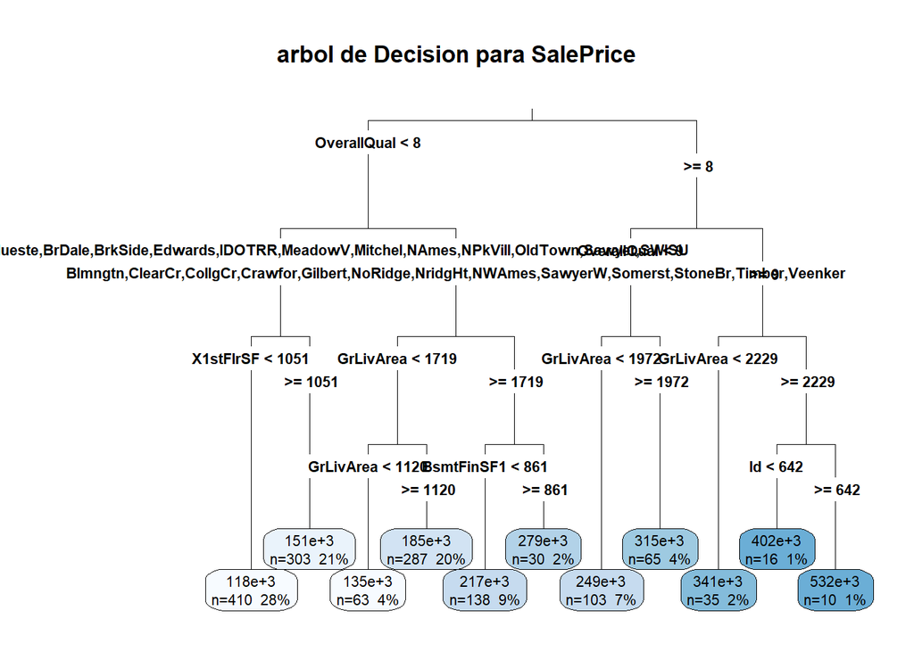

```r
rpart.plot(arbol_8, type = 3, extra = 101, fallen.leaves = TRUE, cex = 0.7, main = "arbol de Decision para SalePrice")
```

y para ver cuál es mejor lo comparamos con la data de entrenamiento:

```r
pre_tree <- function(tree, data, prefix) {

predicciones <- predict(modelo_arbol, training_data)

SSE <- sum((training_data$SalePrice - predicciones)^2)
SST <- sum((training_data$SalePrice - mean(training_data$SalePrice))^2)
R2 <- 1 - (SSE / SST)
cat(prefix, "\n")
cat("R-squared:", R2, "\n")

RMSE <- sqrt(mean((training_data$SalePrice - predicciones)^2))
cat("RMSE:", RMSE, "\n")
}

pre_tree(arbol_2, training_data, "Árbol de 2 Niveles")
```

```
## Árbol de 2 Niveles
## R-squared: 0.7654134
## RMSE: 38464.11
```

```r
pre_tree(arbol_3, training_data, "Árbol de 3 Niveles")
```

```
## Árbol de 3 Niveles
## R-squared: 0.7654134
## RMSE: 38464.11
```

```r
pre_tree(arbol_8, training_data, "Árbol de 8 Niveles")
```

```
## Árbol de 8 Niveles
## R-squared: 0.7654134
## RMSE: 38464.11
```

## Clasificación en 3 variables

Según el histograma de los datos, estos se encuentran altamente sesgados hacia la derecha:

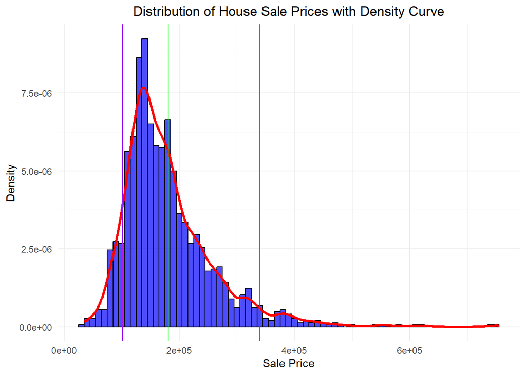

```r
library(ggplot2)

load_data()

mean_price <- mean(training_data$SalePrice, na.rm = TRUE)
sd_price <- sd(training_data$SalePrice, na.rm = TRUE)

# Definir los límites
lower_limit <- mean_price - (1 * sd_price)
upper_limit <- mean_price + (2 * sd_price)

ggplot(training_data, aes(x = SalePrice)) +
  geom_histogram(aes(y = ..density..), binwidth = 10000, fill = "blue", color = "black", alpha = 0.7) +
  geom_density(color = "red", size = 1.2) +
  geom_vline(xintercept = upper_limit, color = "purple")+
  geom_vline(xintercept = lower_limit, color = "purple")+
  geom_vline(xintercept = mean(training_data$SalePrice), color = "green")+
  theme_minimal() +
  labs(title = "Distribution of House Sale Prices with Density Curve",
       x = "Sale Price",
       y = "Density") +
  theme(plot.title = element_text(hjust = 0.5))
```

## Árbol de Clasificación

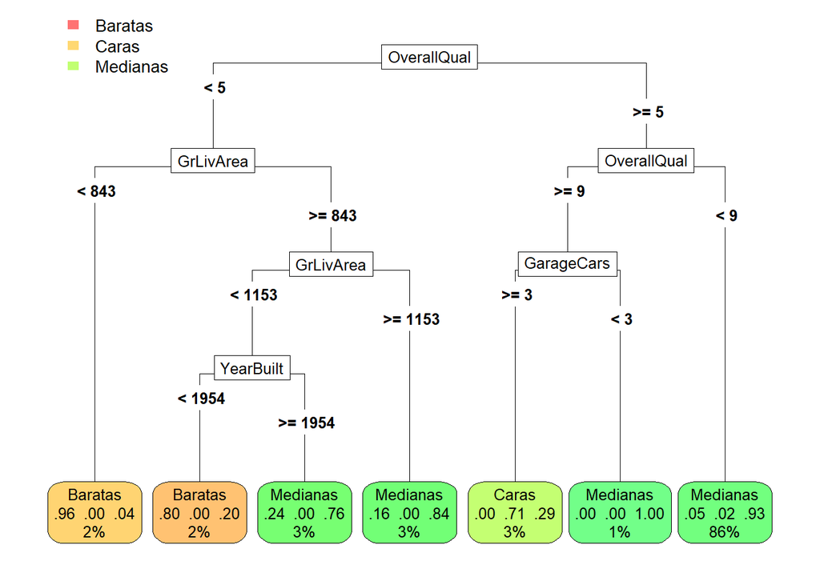

```r
# Cargar librerías
library(rpart)       # Árboles de clasificación
library(rpart.plot)  # Visualización de árboles

# Crear la variable de clasificación
training_data$Category <- ifelse(training_data$SalePrice < lower_limit, "Baratas",
                           ifelse(training_data$SalePrice > upper_limit, "Caras", "Medianas"))
training_data$Category <- as.factor(training_data$Category)

# Revisamos la distribución
# table(training_data$Category)

modelo_arbol <- rpart(Category ~ GrLivArea + OverallQual + GarageCars + YearBuilt,
                      data = training_data,
                      method = "class", # Método de clasificación
                      control = rpart.control(minsplit = 30, cp = 0.01))

# Visualizamos el modelo
rpart.plot(modelo_arbol, type = 5, extra = 104, fallen.leaves = TRUE, cex = 0.8, box.palette = "RdYlGn")
```

## Eficiencia del modelo

```r
probabilidades <- predict(modelo_arbol, test_data, type = "prob")

prod_confidence <- mean(apply(probabilidades, 1, max))

cat("Eficiencia del modelo:",prod_confidence)
```

```
## Eficiencia del modelo: 0.9131478
```

## Matriz de confusión del modelo de clasificación

Acontinuación se muestra la matriz de confusión del modelo:

```r
predicciones <- predict(modelo_arbol, test_data, type = "class")

confusion_matrix <- table(Predicho = predicciones, Real = training_data$Category[-1])

confusion_matrix
```

```
##           Real
## Predicho   Baratas Caras Medianas
##   Baratas        6     2       46
##   Caras          3     3       56
##   Medianas     115    58     1170
```

Podemos ver que el modelo presenta problemas acertando la clasificación de casas baratas y caras. Podemos ver la aparición de falsos negativos, viendo que las clases reales fueron mal clasificadas con otra clase. La presencia de estos falsos negativos y falsos positivos indican que el modelo no es preciso al 100%, demostrando que presenta una mejor predicción para el tipo de casa mediana.

## Modelo con validación cruzada

Ahora vamos a crear un nuevo modelo ahora utilizando la validación cruzada.

```r
library(rpart)
library(caret)
set.seed(123)
splitIndex <- createDataPartition(training_data$Category, p = 0.8, list = FALSE)
train_data <- training_data[splitIndex, ]
test_data <- training_data[-splitIndex, ]
train_control <- trainControl(method = "cv", number = 10)

modelo_tree_cv <- train(Category ~ GrLivArea + OverallQual + GarageCars + YearBuilt,
                        data = train_data,
                        method = "rpart",
                        trControl = train_control,
                        tuneLength = 10)

predicciones <- predict(modelo_tree_cv, newdata = test_data)

confusionMatrix(predicciones, test_data$Category)
```

```
## Confusion Matrix and Statistics
##
##           Reference
## Prediction Baratas Caras Medianas
##   Baratas        9     0        2
##   Caras          0     6        3
##   Medianas      15     6      249
##
## Overall Statistics
##
##                Accuracy : 0.9103
##                  95% CI : (0.8714, 0.9406)
##     No Information Rate : 0.8759
##     P-Value [Acc > NIR] : 0.04089
##
##                   Kappa : 0.5022
##
##  Mcnemar's Test P-Value : NA
##
## Statistics by Class:
##
##                      Class: Baratas Class: Caras Class: Medianas
## Sensitivity                 0.37500      0.50000          0.9803
## Specificity                 0.99248      0.98921          0.4167
## Pos Pred Value              0.81818      0.66667          0.9222
## Neg Pred Value              0.94624      0.97865          0.7500
## Prevalence                  0.08276      0.04138          0.8759
## Detection Rate              0.03103      0.02069          0.8586
## Detection Prevalence        0.03793      0.03103          0.9310
## Balanced Accuracy           0.68374      0.74460          0.6985
```

Con este nuevo modelo podemos ver una mejora significativa en comparación con el modelo anterior. Ahora en la matriz de confusión podemos notar una menor presencia de falsos negativos y falsos positivos.

```r
library(caret)
library(rpart)
library(rpart.plot)

train_control <- trainControl(method = "cv", number = 10)
set.seed(123)

#Modelo con profundidad 3
modelo_3 <- train(Category ~ GrLivArea + OverallQual + GarageCars + YearBuilt,
                  data = training_data,
                  method = "rpart",
                  trControl = train_control,
                  tuneGrid = expand.grid(cp = 0.01),
                  control = rpart.control(maxdepth = 3))

#Modelo con profundidad 5
modelo_5 <- train(Category ~ GrLivArea + OverallQual + GarageCars + YearBuilt,
                  data = training_data,
                  method = "rpart",
                  trControl = train_control,
                  tuneGrid = expand.grid(cp = 0.01),
                  control = rpart.control(maxdepth = 5))

#Modelo con profundidad 7
modelo_7 <- train(Category ~ GrLivArea + OverallQual + GarageCars + YearBuilt,
                  data = training_data,
                  method = "rpart",
                  trControl = train_control,
                  tuneGrid = expand.grid(cp = 0.01),
                  control = rpart.control(maxdepth = 7))

# Precisión de los modelos
acc_3 <- max(modelo_3$results$Accuracy)
acc_5 <- max(modelo_5$results$Accuracy)
acc_7 <- max(modelo_7$results$Accuracy)

data.frame(Profundidad = c(3, 5, 7),
                         Accuracy = c(acc_3, acc_5, acc_7))
```

```
##   Profundidad  Accuracy
## 1           3 0.8952505
## 2           5 0.9013388
## 3           7 0.9041070
```

Se crearan modelos con 3, 5 y 7 niveles de profundidad. Viendo la precisión de cada uno de estos árboles podemos ver que el mejor de los 3 modelos es aquel que tiene 7 niveles, esto demuestra que a mayor profundidad, se tiene una mejor clasificación.

## Random Forest

```r
library(caret)
library(randomForest)
```

```r
library(ggplot2)

train_control <- trainControl(method = "cv", number = 10)

set.seed(123)
modelo_rf <- train(Category ~ GrLivArea + OverallQual + GarageCars + YearBuilt,
                   data = training_data,
                   method = "rf",
                   trControl = train_control,
                   tuneLength = 3)
acc_rf <- max(modelo_rf$results$Accuracy)
acc_tree <- max(modelo_7$results$Accuracy)

data.frame(Modelo = c("Árbol de Decisión", "Random Forest"),
                          Accuracy = c(acc_tree, acc_rf))
```

```
##              Modelo  Accuracy
## 1 Árbol de Decisión 0.9041070
## 2     Random Forest 0.9089261
```

Podemos ver que los random forest presentan una mayor precisión con respecto a los árboles de decisión. Es importante destacar también que la creación de los random forest es mayor a la de los árboles de decisión entonces, viendo que la precisión en este caso no fue muy alta. Lo demuestra que se debe de tomar la decisión entre querer una mejor precisión o una mejor eficiencia algoritmica.